## Watch before tutorial

It is recommended to watch these short videos as a brief and useful introduction to survival analysis

[Survival Analysis | Concepts and Implementation in R](https://www.youtube.com/watch?v=vX3l36ptrTU&list=PLqzoL9-eJTNDdnKvep_YHIwk2AMqHhuJ0) (Videos 1 to 5)

## Install packages

```r
#BiocManager::install("TCGAbiolinks")
#BiocManager::install("survival")
#BiocManager::install("survminer")
```

# 1 What we will learn in this Tutorial

This exercise will show how to get some insight into **Cancer Genome Atlas (TGCA)** data and perform classical analysis on clinical data.

These include:

1. Investigate the retrieved data (clinical and expression) from TGCA
2. Perform survival analysis.

## Load packages

```r
library("TCGAbiolinks")
library("survival")
library("survminer")
library("SummarizedExperiment")
```

# 2 TCGA data

In this tutorial, we will focus on **Liver Hepatocellular Carcinoma**, which is identified in TCGA as *LIHC*. For LIHC, TCGA provides data for 377 patients including: clinical, expression, DNA methylation and genotyping data. In this tutorial, we will work with clinical and expression data (RNA-seq). Go to https://portal.gdc.cancer.gov/ and search for TCGA-LIHC if you want to understand the data deposited in TCGA. You can also try to find your way through the previous data to look for other data sets of your interest.

## Understanding TCGA data

### Data access

GDC provides the data with two access levels:

- Open: includes high level genomic data that is not individually identifiable, as well as most clinical and all biospecimen data elements.
- Controlled: includes individually identifiable data such as low-level genomic sequencing data, germline variants, SNP6 genotype data, and certain clinical data elements

You can find more information about those two levels and how to get access to controlled data at: https://gdc.cancer.gov/access-data/data-access-processes-and-tools.

### TCGA barcode description

Each TCGA sample has a unique identifier called TCGA barcode, which contains important information about each sample. A description of the barcode is shown below (Source: https://docs.gdc.cancer.gov/Encyclopedia/pages/TCGA_Barcode/).

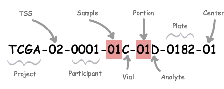

| Label | Identifier for | Value | Value Description | Possible Values |
| --- | --- | --- | --- | --- |
| Analyte | Molecular type of analyte for analysis | D | The analyte is a DNA sample | See Code Tables Report |
| Plate | Order of plate in a sequence of 96-well plates | 182 | The 182nd plate | 4-digit alphanumeric value |
| Portion | Order of portion in a sequence of 100 - 120 mg sample portions | 1 | The first portion of the sample | 01-99 |
| Vial | Order of sample in a sequence of samples | C | The third vial | A to Z |
| Project | Project name | TCGA | TCGA project | TCGA |
| Sample | Sample type | 1 | A solid tumor | Tumor types range from 01 - 09, normal types from 10 - 19 and control samples from 20 - 29. See Code Tables Report for a complete list of sample codes |
| Center | Sequencing or characterization center that will receive the aliquot for analysis | 1 | The Broad Institute GCC | See Code Tables Report |
| Participant | Study participant | 1 | The first participant from MD Anderson for GBM study | Any alpha-numeric value |
| TSS | Tissue source site | 2 | GBM (brain tumor) sample from MD Anderson | See Code Tables Report |

You can find a table with all the code and meanings at https://gdc.cancer.gov/resources-tcga-users/tcga-code-tables. The Sample Type Codes is shown below:

### Sample Type Codes

| Code | Definition | Short Letter Code |
| --- | --- | --- |
| 01 | Primary Solid Tumor | TP |
| 02 | Recurrent Solid Tumor | TR |
| 03 | Primary Blood Derived Cancer - Peripheral Blood | TB |
| 04 | Recurrent Blood Derived Cancer - Bone Marrow | TRBM |
| 05 | Additional - New Primary | TAP |
| 06 | Metastatic | TM |
| 07 | Additional Metastatic | TAM |
| 08 | Human Tumor Original Cells | THOC |
| 09 | Primary Blood Derived Cancer - Bone Marrow | TBM |
| 10 | Blood Derived Normal | NB |
| 11 | Solid Tissue Normal | NT |
| 12 | Buccal Cell Normal | NBC |
| 13 | EBV Immortalized Normal | NEBV |
| 14 | Bone Marrow Normal | NBM |
| 15 | sample type 15 | 15SH |
| 16 | sample type 16 | 16SH |
| 20 | Control Analyte | CELLC |
| 40 | Recurrent Blood Derived Cancer - Peripheral Blood | TRB |
| 50 | Cell Lines | CELL |
| 60 | Primary Xenograft Tissue | XP |
| 61 | Cell Line Derived Xenograft Tissue | XCL |
| 99 | sample type 99 | 99SH |

### Data structure

In order to filter the data available in GDC some fields are available such as project (TCGA, TARGET, etc.), data category (Transcriptome Profiling, DNA methylation, Clinical, etc.), data type (Gene Expression Quantification, Isoform Expression Quantification, Methylation Beta Value, etc.), experimental strategy (miRNA-Seq, RNA-Seq, etc.), Workflow Type, platform, access type and others.

You can find the entry possibilities for each filter at the repository page of the database at https://portal.gdc.cancer.gov/repository.

# 3 Data Description

Data for this Tutorial are RNA-seq data from LIHC project with the id of the project of “TCGA_LIHC”, and the data category we are interested in, i.e. “Transcriptome Profiling”. Here, we will focus on a particular type of data summarization for mRNA-seq data (workflow.type).

The query of data has been done by us, so no need to retrieve the data from **GDC projects**

First load the data:

```r
tcga_data = readRDS(file = "tcga_data.RDS")
```

There are 3 functions that allow us to access to most important data present in this object, these are: `colData()`, `rowData()`, `assays()`.

The functions `colnames()` and `rownames()` can be used to extract the column and rows names from a given table respectively.

```r
colnames(colData(tcga_data))
```

```
##  [1] "barcode"                     "patient"
##  [3] "sample"                      "shortLetterCode"
##  [5] "definition"                  "sample_submitter_id"
##  [7] "is_ffpe"                     "tissue_type"
##  [9] "state"                       "submitter_id"
## [11] "sample_id"                   "sample_type_id"
## [13] "oct_embedded"                "sample_type"
## [15] "initial_weight"              "pathology_report_uuid"
## [17] "days_to_collection"          "classification_of_tumor"
## [19] "days_to_last_follow_up"      "last_known_disease_status"
## [21] "ajcc_pathologic_n"           "primary_diagnosis"
## [23] "ajcc_pathologic_t"           "age_at_diagnosis"
## [25] "ajcc_pathologic_m"           "year_of_diagnosis"
## [27] "icd_10_code"                 "tumor_grade"
## [29] "prior_malignancy"            "ajcc_staging_system_edition"
```

[output cut: 17 more lines]

Lets look at some potentially interesting features. The table() function (in this context) produces a small summary with the sum of each of the factors present in a given column.

```r
table(tcga_data@colData$vital_status)
```

```
##
##        Alive         Dead Not Reported
##          258          164            2
```

```r
table(tcga_data@colData$tumor_stage)
```

```
##
## not reported      stage i     stage ii    stage iii   stage iiia   stage iiib
##           32          191           98            6           73            8
##   stage iiic     stage iv    stage iva    stage ivb
##           10            3            1            2
```

```r
table(tcga_data@colData$definition)
```

```
##
##   Primary solid Tumor Recurrent Solid Tumor   Solid Tissue Normal
##                   371                     3                    50
```

```r
table(tcga_data@colData$tissue_or_organ_of_origin)
```

```
##
## Liver
##   424
```

```r
table(tcga_data@colData$gender)
```

```
##
## female   male
##    143    281
```

```r
table(tcga_data@colData$race)
```

```
##
## american indian or alaska native                            asian
##                                2                              166
##        black or african american                     not reported
##                               24                               13
##                            white
##                              219
```

What about the RNA-seq data? We can use the **assay** function to obtain the RNA-seq count matrices and **rowData** to see gene mapping information. Can you tell how many genes and how many samples are included there?

```r
dim(assay(tcga_data))     # gene expression matrices.
```

```
## [1] 56457   424
```

```r
head(assay(tcga_data)[,1:5]) # expression of first 6 genes and first 10 samples
```

```
##                 TCGA-CC-A3MB-01A-11R-A213-07 TCGA-DD-A4NE-01A-11R-A27V-07
## ENSG00000000003                         6711                         3143
## ENSG00000000005                            0                            0
## ENSG00000000419                         2364                         1600
## ENSG00000000457                         1380                         1461
## ENSG00000000460                          864                          598
## ENSG00000000938                          187                           67
##                 TCGA-5R-AAAM-01A-12R-A41C-07 TCGA-ZS-A9CD-01A-11R-A37K-07
## ENSG00000000003                         3093                         6041
## ENSG00000000005                            0                            0
## ENSG00000000419                         1425                         1377
## ENSG00000000457                          441                          527
## ENSG00000000460                           76                          101
## ENSG00000000938                          363                          198
##                 TCGA-2Y-A9GV-01A-11R-A38B-07
## ENSG00000000003                         3320
## ENSG00000000005                            9
## ENSG00000000419                          815
## ENSG00000000457                          548
## ENSG00000000460                          290
## ENSG00000000938                           90
```

```r
head(rowData(tcga_data))     # ensembl id and gene id of the first 6 genes.
```

```
## DataFrame with 6 rows and 3 columns
##                 ensembl_gene_id external_gene_name original_ensembl_gene_id
##                     <character>        <character>              <character>
## ENSG00000000003 ENSG00000000003             TSPAN6       ENSG00000000003.13
## ENSG00000000005 ENSG00000000005               TNMD        ENSG00000000005.5
## ENSG00000000419 ENSG00000000419               DPM1       ENSG00000000419.11
## ENSG00000000457 ENSG00000000457              SCYL3       ENSG00000000457.12
## ENSG00000000460 ENSG00000000460           C1orf112       ENSG00000000460.15
## ENSG00000000938 ENSG00000000938                FGR       ENSG00000000938.11
```

# 4 Survival Analysis

One analysis often performed on TCGA data is survival analysis. In short, this boils down to answering the following question: how more likely is a certain group of patients to live longer than another?

The techniques we are going to see are not, however, limited to survival (to death events) but can be applied to any experiment where patients can be divided into groups and there is an event, something happening at a specific time point.

To warm up and explain the method, we will start with an easy question: does gender influence survival in liver cancer patients?

TCGA, as mentioned before, provides a lot of clinical data for each patient. We need to extract the gender variable, and a few more besides:

```r
# extract clinical data
clinical = tcga_data@colData

dim(clinical)
```

```
## [1] 424  64
```

```r
# we are only interested in the "Primary solid Tumor" cases for survival
clin_df = clinical[clinical$definition == "Primary solid Tumor",
                    c("patient",
                      "vital_status",
                      "days_to_death",
                      "days_to_last_follow_up",
                      "gender",
                      "tumor_stage",
                      "bmi")]
```

Now we have a new dataframe, `clin_df`, containing only the information that is relevant to survival analysis. In addition to `gender`, we have added `vital_status` (whether patient is alive or dead), `tumor_stage` (from stage 1 to 4) and two important variables: `days_to_death`, that is the number of days passed from the initial diagnosis to the patient’s death (clearly, this is only relevant for dead patients), and `days_to_last_follow_up` that is the number of days passed from the initial diagnosis to the last visit.

Before we can proceed, we need to change part of this information in a way that is acceptable to the methods from the `survival` package we are using:

```r
# create a new boolean variable that has TRUE for dead patients
# and FALSE for live patients
clin_df$deceased = clin_df$vital_status == "Dead"

# create an "overall survival" variable that is equal to days_to_death
# for dead patients, and to days_to_last_follow_up for patients who
# are still alive
clin_df$overall_survival = ifelse(clin_df$deceased,
                                   clin_df$days_to_death,
                                   clin_df$days_to_last_follow_up)

# show first 10 samples
head(clin_df)
```

```
## DataFrame with 6 rows and 9 columns
##                                   patient vital_status days_to_death
##                               <character>  <character>     <integer>
## TCGA-CC-A3MB-01A-11R-A213-07 TCGA-CC-A3MB         Dead           315
## TCGA-DD-A4NE-01A-11R-A27V-07 TCGA-DD-A4NE         Dead           660
## TCGA-5R-AAAM-01A-12R-A41C-07 TCGA-5R-AAAM         Dead            46
## TCGA-ZS-A9CD-01A-11R-A37K-07 TCGA-ZS-A9CD         Dead          1386
## TCGA-2Y-A9GV-01A-11R-A38B-07 TCGA-2Y-A9GV         Dead          2532
## TCGA-BC-A10T-01A-11R-A131-07 TCGA-BC-A10T         Dead           837
##                              days_to_last_follow_up      gender  tumor_stage
##                                           <integer> <character>  <character>
## TCGA-CC-A3MB-01A-11R-A213-07                      3        male   stage iiia
## TCGA-DD-A4NE-01A-11R-A27V-07                     NA      female   stage iiia
## TCGA-5R-AAAM-01A-12R-A41C-07                     NA      female     stage ii
## TCGA-ZS-A9CD-01A-11R-A37K-07                     NA        male     stage ii
## TCGA-2Y-A9GV-01A-11R-A38B-07                     NA      female      stage i
## TCGA-BC-A10T-01A-11R-A131-07                     NA        male not reported
##                                    bmi  deceased overall_survival
##                              <numeric> <logical>        <integer>
## TCGA-CC-A3MB-01A-11R-A213-07   18.7242      TRUE              315
## TCGA-DD-A4NE-01A-11R-A27V-07   27.3356      TRUE              660
## TCGA-5R-AAAM-01A-12R-A41C-07   30.1103      TRUE               46
## TCGA-ZS-A9CD-01A-11R-A37K-07        NA      TRUE             1386
## TCGA-2Y-A9GV-01A-11R-A38B-07   30.4780      TRUE             2532
## TCGA-BC-A10T-01A-11R-A131-07        NA      TRUE              837
```

Let’s now see if male and female patients have had different prognosis (in this dataset).

## Kaplan-Meier plots

As a first step, we need to define a survival formula with the help of the `Surv` object.

#### `Surv()` Function

- The `Surv()` function takes the following arguments:

function (time, time2, event, type = c(“right”, “left”, “interval”, “counting”, “interval2”, “mstate”), origin = 0)

- To use the functions in the `survival` library, we will have to specify both the “survival time” and the “failure indicator” in the `Surv()` function
- When we use the `Surv()` function, we specify the **time variable first** and the **failure indicator second**
- In R, the failure indicator should equal *1 for subjects with the event* and equal *0 for subjects who are right censored*

In R, formulas are special constructs of the form `y ~ x`, and in the context of linear models you can see `x` as the independent variable and `y` as the dependent variable.

This works also for multivariate models: `age ~ gender + height` is a formula that can be used to predict age from gender and height. You can refer to the documentation of formula for further examples and explanations, by typing `?formula` in a R shell.

Let’s get back to survival. We have a categorical variable, `gender`, that needs to be used to separate (or, more appropriately, *stratify*) the available death events.

The `survival` package provides us with an object, `Surv`, to form a dependent variable out of the `overall_survival` and `deceased` information:

```r
Surv(clin_df$overall_survival, clin_df$deceased)
```

```
##   [1]  315   660    46  1386  2532   837  1531+  729+  639    19   299   535
##  [13]  262   412+  594+  802  3308+  449+  854+ 1855+ 1271  1622   101    16
##  [25]  480+  658+  409+ 2028+ 2202+   94+  722+  427+   12   366   107   928+
##  [37]  554+  649   272  2317+  248+  373   419   627     6+ 1636+  468+  359
##  [49]  848   410    36  1049+  768   816+  728+  330+  520+  341+  917+ 2486
##  [61] 2102+ 1900+ 2513+  588+  396+ 1233+ 1779+  363+  555   214   308   910+
##  [73] 1098+ 2015+ 1351+ 2442+ 1450+   15+  444+  129   387+   56  1115+   65
##  [85]  140   423+ 1685   989+  406+ 1149   931   898+  438  1516+  260+ 3478+
##  [97]  327+    0+ 2425+   65  1711+  587+  644+ 1066+   52   250+   91  1553+
## [109] 1242+  848+  137+ 1490   381  3125   390+  636+  500+  408+  211+   23+
## [121]    9   344   349   247   698+  680+ 2412+    9+ 1618+  303+  304   688
## [133]  837   223  1229   744+ 3258    20+  303   425    21+ 1091+  262   395+
## [145]   12+  416  1791   472+  474+ 1085+  662+ 1852  1231+ 1876+    0+  763+
## [157]  770   601  2324+ 1145+ 1989+  347+  655+  942+  860+  354+ 1363+  693
## [169] 2752+  291+  827  1008+ 1970+  602+   20+  849+   30+  399+  300   575+
```

[output cut: 16 more lines]

This modifies our overall survival vector by adding censoring information (the `+` just after the time), which requires a small digression.

This data is *right censored*, meaning that for some patients we only have the time of the last follow up but we don’t know if they died at a later date or not.

These patients are kept in the early stages of the analysis (eg, they are part of the survival curve) but they are dropped (or as it is said, *censored*) when the time of their last follow up arrives.

Now that the survival time has been tagged with the censoring, we can add the categorical independent variable `gender`, and effectively create a formula

```r
Surv(clin_df$overall_survival, clin_df$deceased) ~ clin_df$gender
```

```
## Surv(clin_df$overall_survival, clin_df$deceased) ~ clin_df$gender
```

We now have a survival formula that can be passed to the `survfit` function to fit the survival model, and then to another function to produce the Kaplan-Meier plots. Actually, when executing the survival analysis with `survfit`, we can exclude the `clin_df$` if we tell the function to use `clin_df` as data by using the `data=` parameter.

```r
# fit a survival model
fit = survfit(Surv(overall_survival, deceased) ~ gender, data=clin_df)

print(fit)
```

```
## Call: survfit(formula = Surv(overall_survival, deceased) ~ gender,
##     data = clin_df)
##
##    1 observation deleted due to missingness
##                 n events median 0.95LCL 0.95UCL
## gender=female 121     51   1490    1005    2456
## gender=male   249     79   2486    1423      NA
```

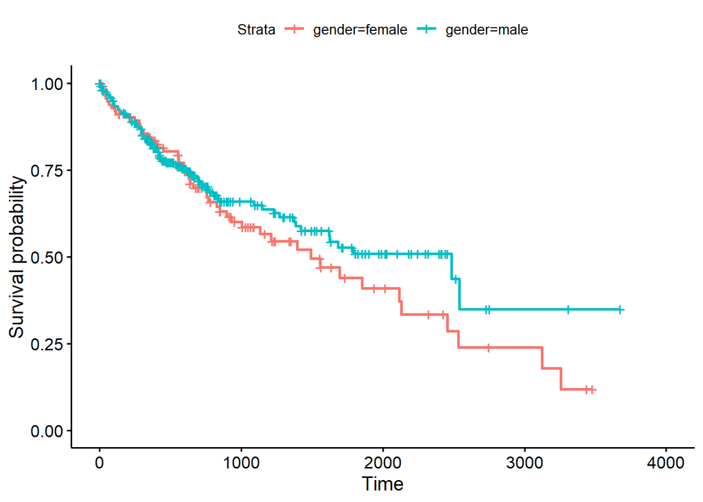

```r
# we produce a Kaplan Meier plot
ggsurvplot(fit, data=clin_df)
```

This Kaplan-Meier plot shows two very similar trends until almost the 2000-day mark, where females seem to have a worse survival probability. But is there a significant difference?

The difference between two such “event curves” is best tested via the *logrank test*, which is, fundamentally, a repeated test of independence. `survminer` will add the p-value of such test if we tell it to do so:

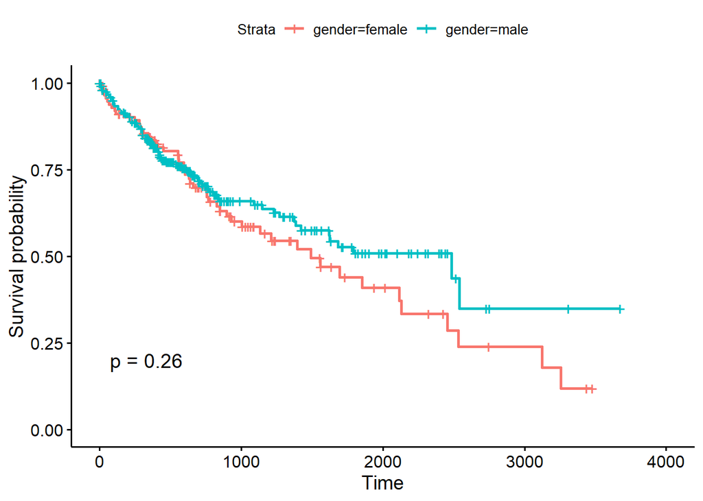

```r
ggsurvplot(fit, data=clin_df, pval=T)
```

The p-value is non-significant, so gender alone does not significantly sway prognosis in this dataset.

If you find this strange because the curves deviate at the 2000-day mark, you have to remember that the **amount of patients involved matters**. At that point, only a few patients remain, and any difference is likely to not be significant.

Can we see the number of patients dying (or being “censored”) as *Time* increases? Indeed we can, with what is called the “at risk table”.

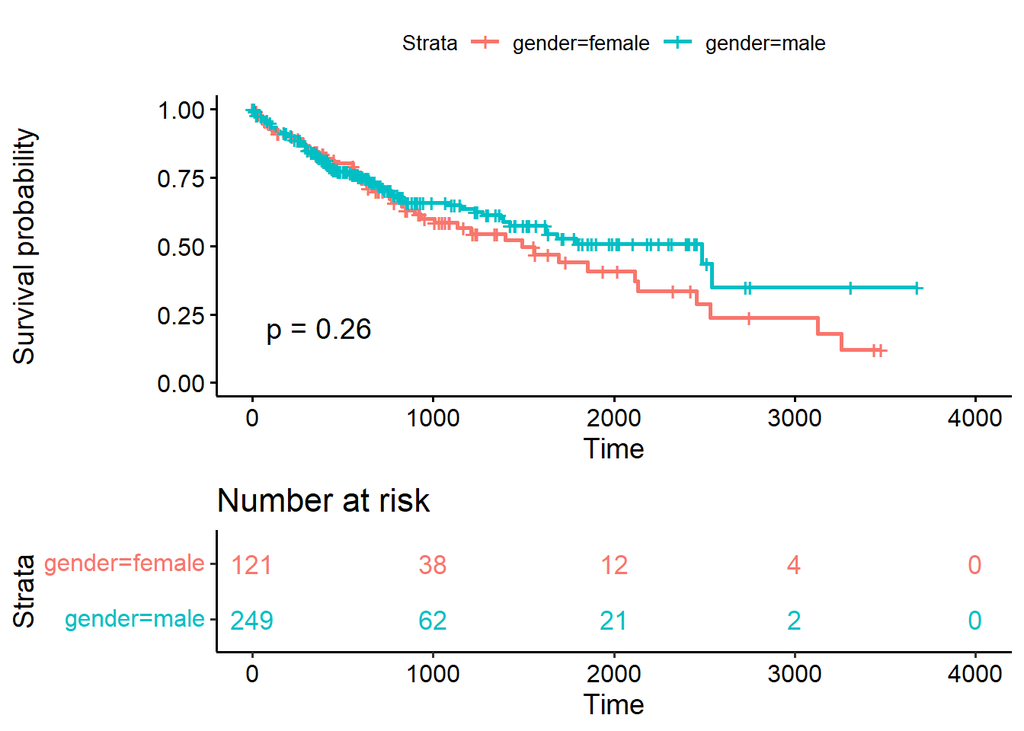

```r
ggsurvplot(fit, data=clin_df, pval=T, risk.table=T, risk.table.col="strata", risk.table.height=0.35)
```

With the `risk.table=T` argument, we get the number of patients “at risk”, that is *neither dead nor censored* at a certain time point.

The argument `risk.table.col="strata"` tells `survminer` to colour the table in the same way as the *strata*, or groups, are coloured.

You can see that most of the patients die or are censored before the 2000-day mark, and therefore it makes sense that the p-value would not be significant.

Another question could be: **how does tumor stage affect survival?**

The `tumor_stage` variable that TCGA provides for this tumor contains both stages and sub-stages, eg *stage iiia* or *stage ivb*. We want to join together the sub-stages, to increase the group size and reduce complexity (and thus increase the power of the logrank statistics).

```r
# remove any of the letters "a", "b" or "c", but only if they are at the end
# of the name, eg "stage iiia" would become simply "stage iii"
clin_df$tumor_stage = gsub("[abc]$", "", clin_df$tumor_stage)

# we remove those with stage "not reported", since they are unknown
clin_df[which(clin_df$tumor_stage == "not reported"), "tumor_stage"] = NA

# finally, we also remove those with tumor stage 4, since they are too few
clin_df[which(clin_df$tumor_stage == "stage iv"), "tumor_stage"] = NA

table(clin_df$tumor_stage)
```

```
##
##   stage i  stage ii stage iii
##       171        86        85
```

```r
fit = survfit(Surv(overall_survival, deceased) ~ tumor_stage, data=clin_df)

# we can extract the survival p-value and print it
pval = surv_pvalue(fit, data=clin_df)$pval
print(pval)
```

```
## [1] 1.215259e-05
```

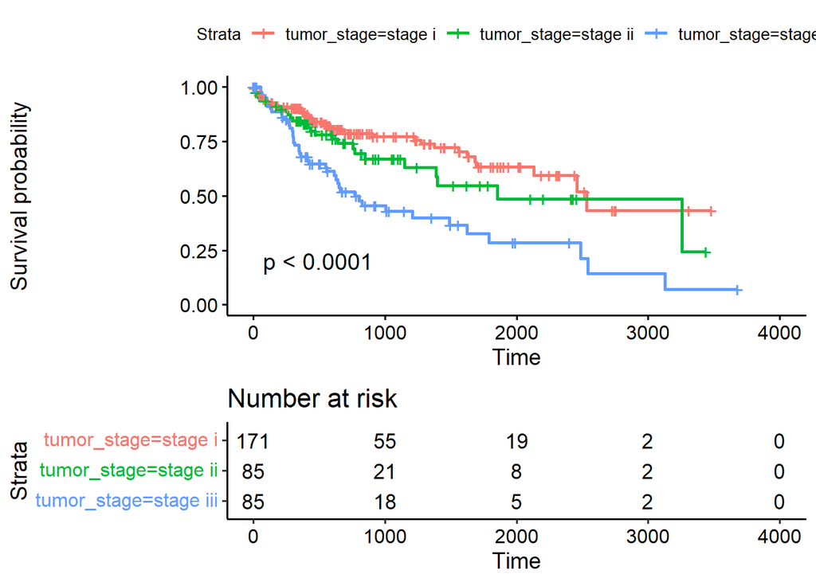

```r
# we produce a Kaplan-Meier plot from the fitted model
ggsurvplot(fit, data=clin_df, pval=T, risk.table=T, risk.table.height=0.35)
```

We get an overall p-value testing the null hypothesis that all the curves are similar at every time point. In this case, the p-value is small enough that we can reject the null hypothesis.

What we saw here is an easy way of producing Kaplan-Meier plots to investigate survival, as well as evaluating whether the survival curves are significantly different or not. A more interesting application to this is using, for example, gene expression to divide the patients into groups, to see whether up or down regulation of genes affects survival. We’ll see this in the next section.

## Self-test:

**how does race affect survival?** comparison between **“white”**, **“asian”**, **“black or african american”** , and **“others”**. Hint: stack all non-(white/asian/black) into “**others**”

1. Please plot **survival probability** and **risk table**
2. Interpret the results with/without p-value

#### FAQ:

1. is the “tcga_data.RDS” file supposed to be the “tcga_data.rar” file? I’m having some trouble opening it even when changing the extension from .rar to .RDS.

   **Answer**: just need to download a file extractor to open .rar files.
2. I was wondering how to go about stacking the non-black/white/asian entries into “other”. Would we have to use a loop of any kind?

**Answer**: The simplest method is to use `which` and `indexing`